# Data Processing and Exploratory Data Analysis

Haojia Li

June 20, 2020

# Empire State Poll (ESP)

## Data Description

| Demographics | N(%) |
| --- | --- |
| Gender |  |
| Male | 403(50.38%) |
| Female | 393(49.12%) |
| Other | 2(0.25%) |
| Refused | 2(0.25%) |
| Age |  |
| 18-20 | 42(5.25%) |
| 21-44 | 298(37.25%) |
| 45-64 | 286(35.75%) |
| 65+ | 168(21%) |
| Refused | 6(0.75%) |
| Education |  |
| High school or less | 184(23%) |
| Some college or associate’s degree | 224(28%) |
| Bachelor’s degree or higher | 390(48.75%) |
| Refused | 2(0.25%) |
| Income |  |
| <$50k | 253(31.62%) |
| $50k-$100k | 262(32.75%) |
| $100k-$150k | 112(14%) |
| $150k+ | 143(17.88%) |
| No Data | 30(3.75%) |
| Race |  |
| White | 543(67.88%) |
| Black | 103(12.88%) |
| Asian | 44(5.5%) |
| Natam | 10(1.25%) |
| More than 1 race | 38(4.75%) |
| Other | 51(6.38%) |
| Refused | 11(1.38%) |
| Ethnicity |  |
| Hispanic | 126(15.75%) |
| Non-hispanic | 671(83.88%) |
| Refused | 3(0.38%) |

**Study Population:** New York State residents aged 18 and over.

**Data Source:** Empire State Poll (ESP) 2019, a random-digit-dial telephone survey conducted by the Survey Research from February to April in 2019 that covers 800 completed interviews. 400 (50%) of the participants were from downstate and the rest were from upstate. **Study Variables**

1. Outcomes
- `JAq4` - self-reported health status
  - 1 = Excellent
  - 2 = Very Good
  - 3 = Good
  - 4 = Fair
  - 5 = Poor
- `RVq2` - visits to care providers in the past 12 months
  - 1 = Never
  - 2 = 1-2 times
  - 3 = Once every few months
  - 4 = Once a month
  - 5 = Twice a month
  - 6 = Once a week
  - 7 = 2-3 times a week
2. Predictors
- SNS-3: 3-item version of the Subjective Numeracy Scale (SNS), which was validated having good internal reliability and correlated highly with the full SNS.
  - `JAq1` - rate competence related to fractions (1 = *not good at all* to 6 = *extremely good*)
  - `JAq2` - rate competence related to percentages (1 = *not good at all* to 6 = *extremely good*)
  - `JAq3` - rate usefulness related to numerical information (1 = *never* to 6 = *very often*)
3. Covariates
- Demographical variables
  - `gender` 1=Male, 2=Female, 3=Other, -1=Refused
  - `age` 18-20, 21-44, 45-64, 65+, -1=Refused
  - `educ` 1-3=“High school or less”, 4-5=“Some college or associate’s degree”, 6-7=“Bachelor’s degree or higher”, -1=Refused
  - `hhince` household income in 2018 before taxes ($): 1-5=“<50k”, 6-7=“50k-100k”, 8=“100k-150k”, 9=“150k+”, NA=“No Data”
  - `race` White, Black, Natam, Asian, Other, More than 1 race, -1=Refused
  - `hisp` ethnicity: 0=Non-Hispanic, 1=Hispanic, -1=Refused

**Distribution of Health Score:** the distribution of self-stated health status is right skewed. The median is 3 (“Good”) and more than 75% of the interviewees had health status equal to or better than “Good”.

Health status

| 0% | 25% | 50% | 75% | 100% |
| --- | --- | --- | --- | --- |
| 1 | 2 | 3 | 3 | 5 |

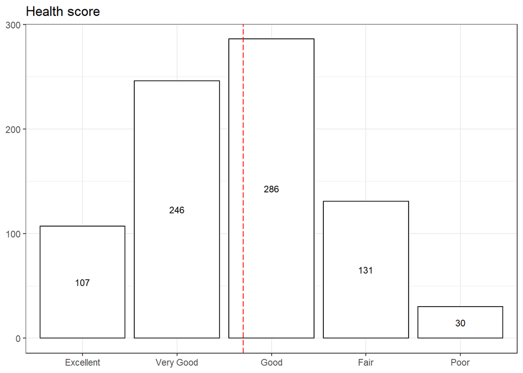

**Distribution of Care Provider Visits:** the distribution of care provider visits is right skewed. The median is 3 (“Once every few months”) and more than 75% of the interviewees had the visit frequency equal to or less than “Once every few months”.

Care provider visits

| 0% | 25% | 50% | 75% | 100% |
| --- | --- | --- | --- | --- |
| 1 | 2 | 3 | 3 | 7 |

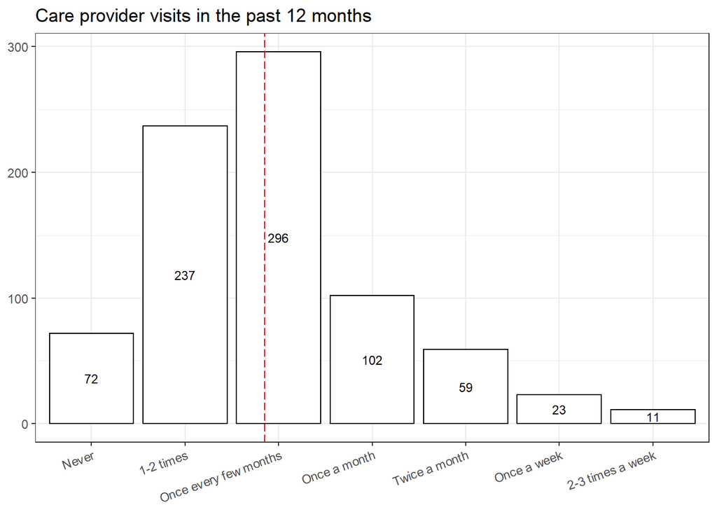

**Distribution of the Combination of Care Provider Visits and Health Status**

The heatmap shows that the top 4 cells of care provider visits and health status are: (Once every few months, Good), (Once every few moths, Very Good), (1-2 times, Good) and (1-2 times, Very Good), which is consistent with the previous results of the distribution of health status or care provider visits alone.

Horizontally reading the plot, we infer that people with excellent health status tend to have lower frequency than the other groups, and that people under poor health condition will visit care providers more than others. However, especially for the poor group, we are not 100% confident to draw such a conclusion since the number of interviewees involved in this subgroup was limited.

On the other hand, based on the distribution of health status in each subgroup of visits, there is no obvious difference among the first 6 groups but only people who visit care providers the most frequently (2-3 times a week) are more likely to have not good health condition.

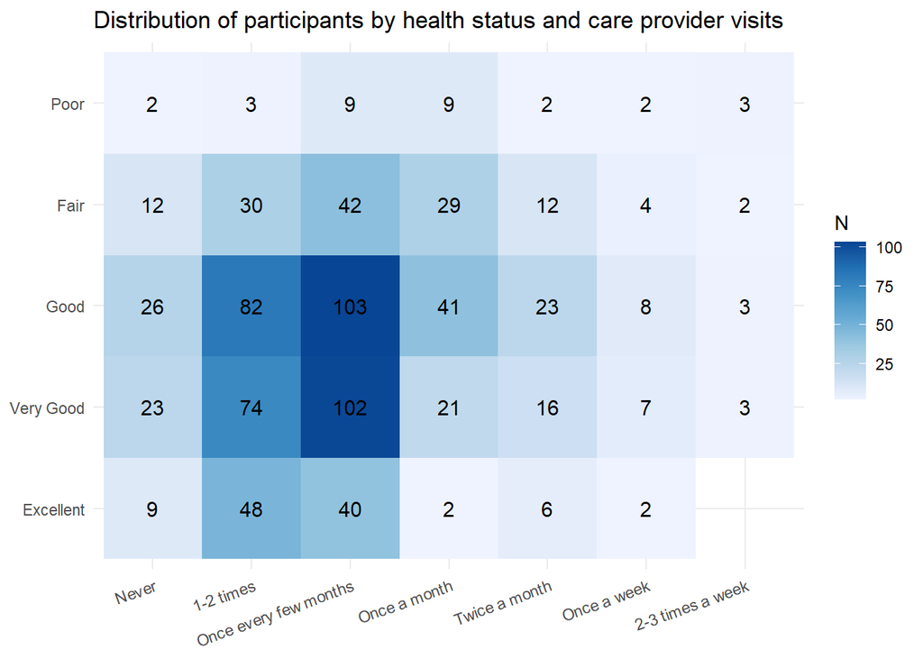

## Data Processing for Regression

**Discussion about Refusal Rate and Missing Values**

- Refusal rate: the refusal rate of race and age are higher than the other variables. For further analysis, we will keep the missing values of race, ethnicity and gender and otherwise drop those of others.
- Missing values: for further analysis, we will keep the missing values of race, ethnicity and gender and otherwise drop those of others.

Refusal Rate (if any)

|  | Race | Age | Ethnicity | Gender | Education | JAq1 | JAq2 | JAq3 |
| --- | --- | --- | --- | --- | --- | --- | --- | --- |
| Number | 11.00 | 6.00 | 3.000 | 2.00 | 2.00 | 2.00 | 3.000 | 3.000 |
| % | 1.38 | 0.75 | 0.375 | 0.25 | 0.25 | 0.25 | 0.375 | 0.375 |

JAq1: How good are you at working with fractions?  
JAq2: How good are you at figuring out how much a shirt will cost if it is 25% off?  
JAq3: How often do you find numerical information to be useful?

**Calculation of Numeracy Score**

For further analysis (regression), the sum of `JAq1`, `JAq2` and `JAq3` will serve as the predictor of the model. Though almost all the answers were with positive value, which we would like to call as “correct” answers, there were a few “incorrect” answers with value -1=“Refused” and -2=“Don’t know”.

2 participants had more than half (2) wrong answers, so they were dropped from the dataset. 11 had only 1 wrong answer and the these negative values will be imputated using the average score of all the other correct answers across each SNS item 4.74.

Finally 798 participants were kept and we got the final predictor `numeracy`.

**Demographical Comparison Table: New York State vs. ESP**

This comparison is aimed to compare the the sample distribution of ESP with the population of New York State (NYS). All the data of NYS was found in the tables [United States Census Bureau](https://www.census.gov). Since the data of each demographical characteristics was collected from different tables, the total numbers (in thousand)were close but may be not equal to each other.

Apart from dropping some missing values, we collapsed the levels of `race` into 3: White, Black and Other.

We performed Fisher’s test to evaluate the difference between ESP sample and NYS population. The p-value less than 0.05 indicates that it is worth considering to add weight (the proportion of each subgroup in NYS) into the regression model.

Based on the table below, we find that:

- There is no significant difference in `gender`, `age` and `ethnicity`.
- There is significant difference in `education`, `income` and `race`.
  - People with higher education / income level tend to have higher will to be interviewed.
  - Among the participants, the proportion of white people were closed to that in NYS. The reason why there were significant difference was ESP had lower proportion of black people involved than the group other than white and black.

| Demographics | NYS | ESP | pval |
| --- | --- | --- | --- |
| Gender |  |  | 0.168 |
| Male | 121301(48.41%) | 389(50.78%) |  |
| Female | 129262(51.59%) | 375(48.96%) |  |
| Age |  |  | 0.141 |
| 18-20 | 11851(4.73%) | 41(5.35%) |  |
| 21-44 | 103469(41.29%) | 289(37.73%) |  |
| 45-64 | 82455(32.91%) | 276(36.03%) |  |
| 65+ | 52788(21.07%) | 160(20.89%) |  |
| Education |  |  | <0.001 |
| High school or less | 97506(38.92%) | 174(22.72%) |  |
| Some college or associate’s degree | 69577(27.77%) | 217(28.33%) |  |
| Bachelor’s degree or higher | 83478(33.32%) | 375(48.96%) |  |
| Income |  |  | <0.001 |
| <$50k | 51303(33.03%) | 253(33.03%) |  |
| $50k-$100k | 64932(41.8%) | 260(33.94%) |  |
| $100k-$150k | 19158(12.33%) | 110(14.36%) |  |
| $150k+ | 19930(12.83%) | 143(18.67%) |  |
| Race |  |  | <0.001 |
| White | 13559(69.7%) | 523(68.28%) |  |
| Black | 3424(17.6%) | 99(12.92%) |  |
| Other | 2471(12.7%) | 144(18.8%) |  |
| Ethnicity |  |  | 0.464 |
| Hispanic | 41217(16.47%) | 118(15.4%) |  |
| Non-hispanic | 209046(83.53%) | 647(84.46%) |  |

## Exploratory Data Analysis

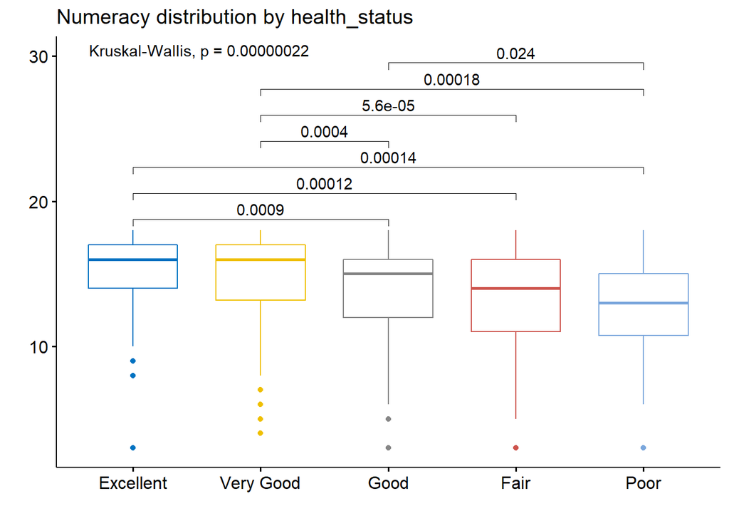

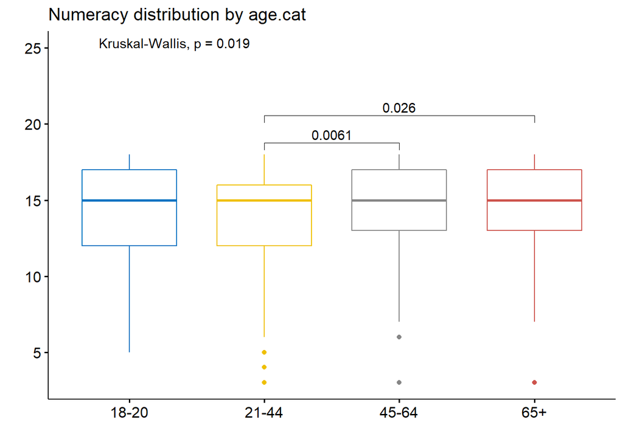

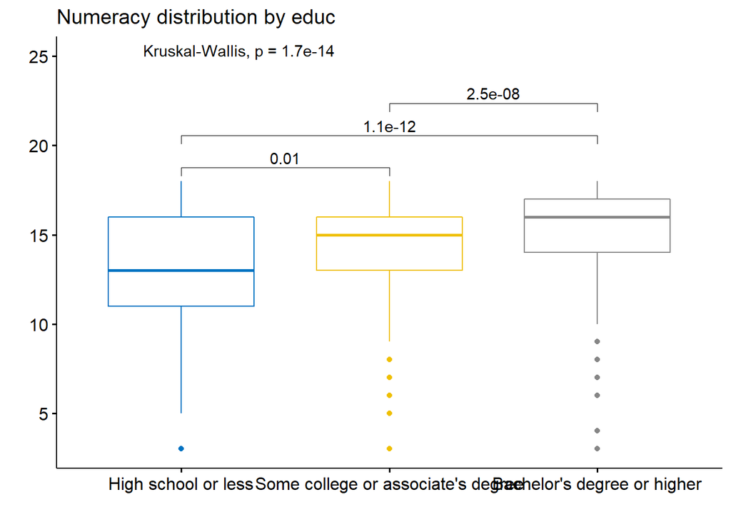

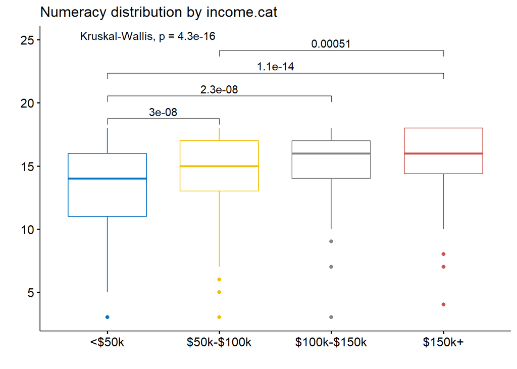

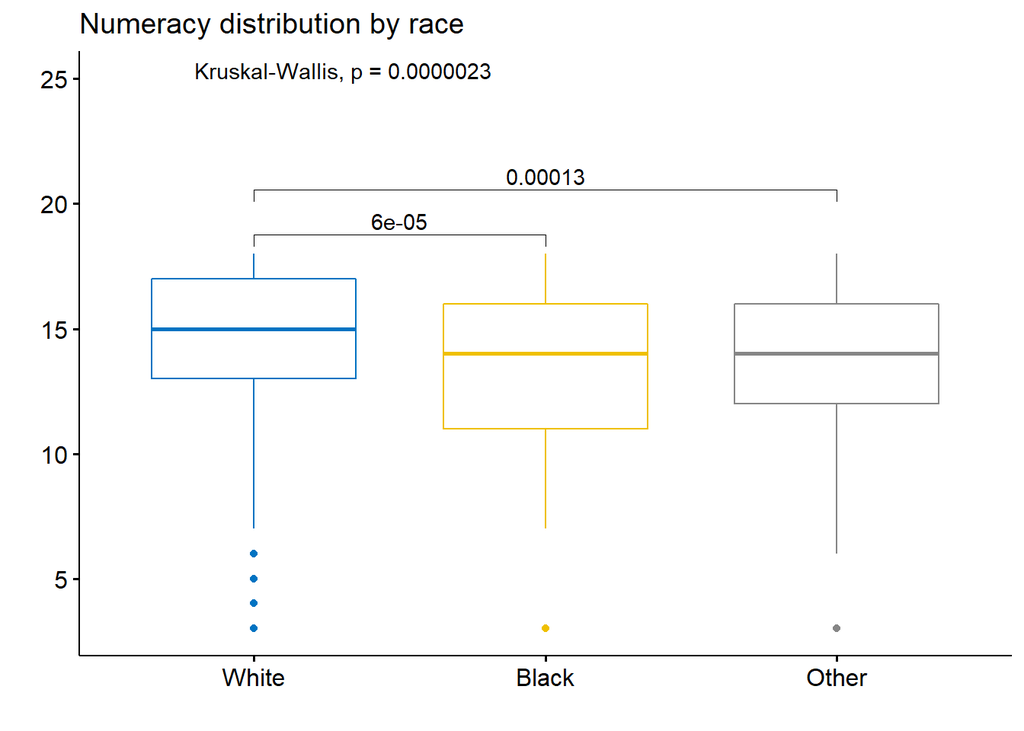

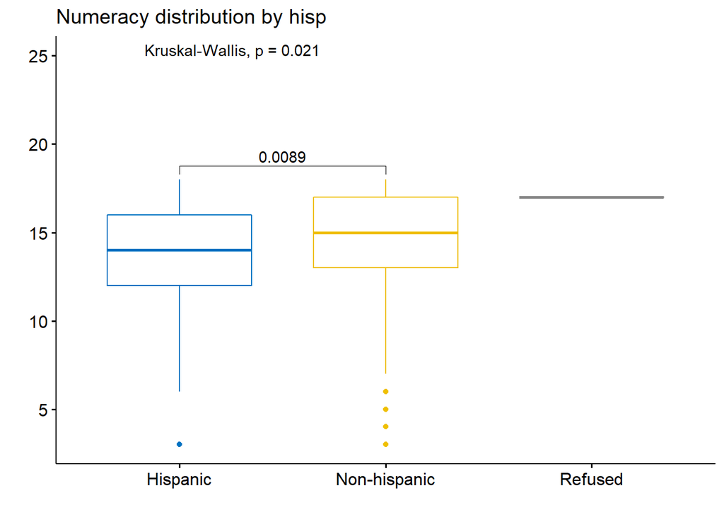

# PIAAC

```
## [[1]]
##
##    0   10
## 3479  181
##
## [[2]]
##
##    0   10
## 3479  181
##
## [[3]]
##
##    0   10
## 2872  788
```

```
## [1] 181
```

```
## [1] 181
```

```
## [1] 181
```

```
##
## FALSE  TRUE
##     4   181
```

Missing data can occur when some of the adults selected in the sample are not accessible or refuse to participate, when they fail to respond to a particular survey item, or, because data collected from the sampled adults are contaminated or lost during or after the data collection phase.

```
## [1] 3660
```

```
## [1] 3475
```

```
## [1] 2609   14
```